# Assignment Report

Vishesh Kakarala

February 11, 2017

# 1. How would you validate the data?

- Steps to ensure I’m working on the right dataset,
  - Accuracy - validating the source of the data, void in this case.
  - Completeness - The brief for the question was to analyze 30 days of clickstream data, which was present
  - Consistency - Took different data samples to check if the data extraction code I wrote provides consistent results with randomly selected files before using it to extract the entire dataset.
  - Interpretability - Visually analyzing the data, to understand the value that can be extracted from the available data.

# 2. How would you normalize the data and make it representative?

For the purpose of this Analysis, - URL of the site was extracted from the Request URL - Server request timestamp was used to identify the user activity - User IP was extracted to identify users

# 3. What different data products you could possibly build that give someone a view into a company’s performance?

A Dashboard to identify Key metrics can be built using the available Data.

https://visheshkakarala.shinyapps.io/deploy/

I’ve built a static example of a web analytics dashboard with the Dataset.

First Panel Displays User behavior Information.

```
+ It shows the Total Number of returning Users per month
+ Second Box average time spent by each user between sessions
+ Average Unique Visitors/day for the given month
```

# Cont.

Visits to site identify that a potential user has seen the site, different data products can be build to measure metrics pertaining to:

- Uniques visitors
  - daily Uniques visitors
  - monthly unique visitors
  - overall unique visitors

Identifying Unique visitors can be done using the IP address, but a sharper user profile can be obtained if we can track sessionID of visitors.

# Cont.

For visitors from Social network sites, we can also extract user ID from session URL or cookies to identify unique visitors

- The Second Panel displays information pertaining to overall metrics
  - Top 10 domains by click volume
  - Day Wise Clicks to understand weekly visitor volume
  - Hour wise Clicks

The Third Panel can be used to compare metrics between visitors from different domains

# 4. From clickstream data, how would you identify performance drivers for a specific company?

Time Spent on site

Time Spent is a low hanging fruit in understanding user behavior, whether the companies website is content driven or product driven time spent translates to user engagement

Bounce rate

Bounce rate is important for every type of company, the sole exception being blog sites where the probability of the user to move on without clicking is high. To move on with a single page view would mean that the user is not interested in the product that the website is offering

# Cont.

Pages/visit

Analyzing Pages/visit gives the company an insight into the level of engagement with each visitor.

Conversion rate

Successful Outcomes/Total visitors is an all important metric to identify and track the success of the company’s online marketing strategy. All of the other metrics are supplementary to conversion rate i.e they help in getting the user to do what you want them to do.

# Cont.

Customer behavior segmentation

We can segment each visitor based on where they come from,

- Direct Traffic
- Referring Sites
- Search Engines

Analyzing each visitor category separately we can pinpoint seasonal or demographic behavior and target these visitors individually.

Behavior segmentation also helps in tracking campaign effectiveness. Identifying the conversion rates from each of the various streams of the advertising that the company has invested in can help to strengthen user acquisition and also increase customer engagement.

# 5. What can you identify the user profile of a select set of domains like amazon, Netflix, Priceline etc.?

User engagement is highest on Staurday for Amazon and Facebook, whereas user engagement is highest for netflix on wednesdays.

Understanding site visitors through referral websites - Here I’ve analyzed the window titles of different domain users to understand the content they are consuming. With a larger dataset, this could give us a good insight into current customer trends and engagement patterns

# Amazon Word Cloud

[figure not shown]

Amazon Wordcloud

# Netflix Word Cloud

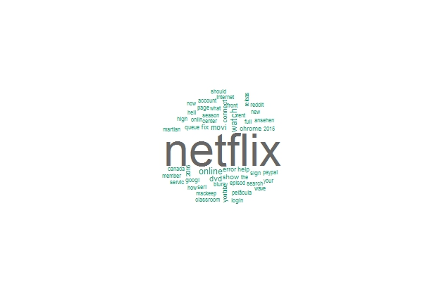

Netflix Word Cloud

# Facebook Word Cloud

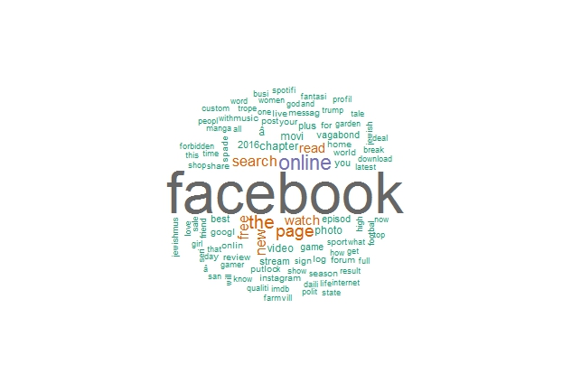

Facebook Word Cloud

# 6. Any other ideas on what could be done with this dataset?

The hourly data can be improved, the sample provided has an activity for each day between only two hours. Visualizing hourly visitor behavior and click volume is a direct metric that can be useful in identifying customer behavior

The small size of the Dataset can be used to build and test models to predict user behavior from different domains. However, in order to obtain value from such a model it will have to be trained on a bigger dataset.

# 7. Explain the pros and cons of the toolsets/packages/models/algorithms you use to answer the above questions

- Python - excellent for data extraction, not so great for analysis
- Due to memory constraints used MongoDB for extraction and joining the JSON dataset
- R- bad for data extraction, excellent for data analysis
- Shiny - Easy to Build and Deploy, does not scale well.

# Assumptions

- Each event is a user visit
- Server timestamp is time of event occurrence
- Each Unique Ip is identified as User, due to absence of session cookies
- Time spent is calculated between first and last request on each day for the user since data is present only for two hours quite possibly single session usage. Not feasible for full hourly data.